# 32-fuel-forecast

The purpose of this notebook is forecasting - using both current features and by generating new features based upon the originals with assumptions. The forecasts should also be tested here to ensure that they meet expectations and assumptions about them.

# Load cleaned data

|  | state | vmt |
| --- | --- | --- |
| 2 | Alabama | 6.792100e+10 |
| 3 | Alaska | 5.306000e+09 |
| 4 | Arizona | 6.575800e+10 |
| 5 | Arkansas | 3.391900e+10 |
| 6 | California | 2.998120e+11 |
| 7 | Colorado | 4.864200e+10 |
| 8 | Connecticut | 2.984500e+10 |
| 9 | Delaware | 8.345000e+09 |
| 10 | District of Columbia | 3.030000e+09 |
| 11 | Florida | 2.080760e+11 |

[output cut: 44 more lines]

# Calculate Ratio AZ VMT to US VMT

```r
value_az_vmt
```

```
[1] 6.5758e+10
```

## Arizona LDV VMT represents the same proportion of the state total VMT as national LDV VMT does to national total VMT

### Data from both FHWA and BTS support that national LDV VMT makes up 89.05% of all national motor vehicle VMT

### Assume same is true for Arizona

### https://www.fhwa.dot.gov/policyinformation/statistics/2020/vm1.cfm

### https://www.bts.gov/browse-statistical-products-and-data/freight-facts-and-figures/vehicle-miles-traveled-highway

## Each LDV travels approximately the same number of miles, regardless of type

### Supported by data from DOE that shows cars, light trucks, busses, and delivery trucks have about the same annual VMT

### https://afdc.energy.gov/data/10309

# Estimate Arizona VMT forecast

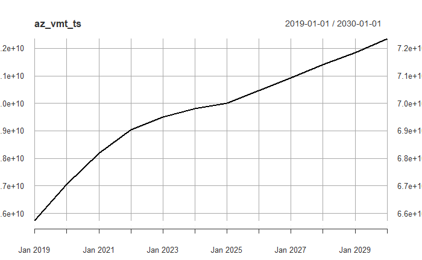

```r
az_vmt_ts = vmt_ts * az_vmt_ratio
plot(az_vmt_ts)
```

```r
az_vmt_ts
```

```
                  [,1]
2019-01-01 65749367155
2020-01-01 67056690877
2021-01-01 68183694085
2022-01-01 69040216523
2023-01-01 69513557870
2024-01-01 69806578704
2025-01-01 70009439282
2026-01-01 70460240565
2027-01-01 70933581912
2028-01-01 71406923260
2029-01-01 71857724543
2030-01-01 72353605954
```

```r
value_az_vmt
```

```
[1] 6.5758e+10
```

# Assign VMT to Stock

The following section assigns VMT to each Arizona vehicle by type. For each year, the average VMT per LDV is calculated. Then, each LDV type has its stock multiplied by the average VMT. The result is a time series showing total VMT per type per year.

```r
#az_stock_adj_ts = readRDS("answers/az_ldv_stock_2019_2030")

az_vmt_per_type_ts = az_stock_adj_ts

for (x in 1:12){

  ann_veh_sum = sum(az_vmt_per_type_ts[x,1:32])

  ann_vmt = az_vmt_ts[x]

  vmt_per_veh = as.numeric(ann_vmt / ann_veh_sum) #checks out with national average VMT per vehicle

  #by dividing each year's AZ VMT (ann_vmt) by the total AZ stock of vehicles that year (ann_veh_sum), we get an average vmt per LDV vehicle in AZ

  for (y in 1:32){

    az_vmt_per_type_ts[x,y] = az_vmt_per_type_ts[x,y] * vmt_per_veh

    #each year, we multiply each LDV stock by vmt_per_veh, yielding total vmt per LDV type per year
  }
}

az_vmt_per_type_ts
```

```
           conventional_cars_gasoline_stock conventional_cars_tdi_diesel_stock
2019-01-01                      31392799490                          191649173
2020-01-01                      29358775385                          185337450
2021-01-01                      27112350531                          178037497
2022-01-01                      24690889836                          169913639
2023-01-01                      22096310854                          160639661
2024-01-01                      19449008361                          150809204
2025-01-01                      16803042851                          140581621
2026-01-01                      14227326341                          130506946
2027-01-01                      11663601752                          120038844
2028-01-01                       9089970909                          109527586
2029-01-01                       6504555695                           99175932
2030-01-01                       3920885405                           89574059
           alternative_fuel_cars_ethanol_flex_fuel_ice_stock
2019-01-01                                        1264826205
2020-01-01                                        1275919632
2021-01-01                                        1275572941
2022-01-01                                        1263258888
2023-01-01                                        1236087442
2024-01-01                                        1199534086
2025-01-01                                        1155780085
2026-01-01                                        1110762786
2027-01-01                                        1060569480
2028-01-01                                        1007322699
2029-01-01                                         951737785
2030-01-01                                         898562472
           alternative_fuel_cars_100_mile_electric_vehicle_stock
2019-01-01                                              63529442
2020-01-01                                             129654512
2021-01-01                                             195923718
2022-01-01                                             261916595
2023-01-01                                             326161346
2024-01-01                                             388810444
2025-01-01                                             450156414
2026-01-01                                             512529052
2027-01-01                                             574892502
2028-01-01                                             637372102
2029-01-01                                             699842664
2030-01-01                                             763190360
           alternative_fuel_cars_200_mile_electric_vehicle_stock
```

[output cut: 296 more lines]

```
2029-01-01                                                      0
2030-01-01                                                      0
           alternative_fuel_light_trucks_fuel_cell_hydrogen_stock
2019-01-01                                                  0.000
2020-01-01                                               1554.801
2021-01-01                                               3661.128
2022-01-01                                               6832.611
2023-01-01                                              10760.102
2024-01-01                                              16205.335
2025-01-01                                              23666.064
2026-01-01                                              33517.950
2027-01-01                                              45479.300
2028-01-01                                              60359.682
2029-01-01                                              78434.759
2030-01-01                                              99595.860
```

```r
value_az_ev
```

```
[1] 28770
```

# Assign gallons per type per year using fuel economy

```r
gallons_ts
```

```
           conventional_cars_gasoline_stock conventional_cars_tdi_diesel_stock
2019-01-01                        781754260                            3801447
2020-01-01                        717602258                            3641442
2021-01-01                        642140613                            3434865
2022-01-01                        557234228                            3183675
2023-01-01                        478555548                            2932875
2024-01-01                        410875579                            2702314
2025-01-01                        339650130                            2412747
2026-01-01                        287491544                            2243151
2027-01-01                        236087587                            2065666
2028-01-01                        184282720                            1887465
2029-01-01                        132076024                            1711147
2030-01-01                         79691766                            1545930
           alternative_fuel_cars_ethanol_flex_fuel_ice_stock
2019-01-01                                          30969052
2020-01-01                                          30632593
2021-01-01                                          29641528
2022-01-01                                          27943984
2023-01-01                                          26245775
2024-01-01                                          24857267
2025-01-01                                          22824495
2026-01-01                                          21929182
2027-01-01                                          20969045
2028-01-01                                          19945229
2029-01-01                                          18871059
2030-01-01                                          17826999
           alternative_fuel_cars_100_mile_electric_vehicle_stock
2019-01-01                                              570138.9
2020-01-01                                             1153139.0
2021-01-01                                             1706360.7
2022-01-01                                             2230584.1
2023-01-01                                             2705683.2
2024-01-01                                             3176727.8
2025-01-01                                             3594871.0
2026-01-01                                             4091742.7
2027-01-01                                             4589606.7
2028-01-01                                             5089175.6
2029-01-01                                             5588948.0
2030-01-01                                             6095216.7
           alternative_fuel_cars_200_mile_electric_vehicle_stock
```

[output cut: 296 more lines]

```
2029-01-01                                                      0
2030-01-01                                                      0
           alternative_fuel_light_trucks_fuel_cell_hydrogen_stock
2019-01-01                                                0.00000
2020-01-01                                               38.68889
2021-01-01                                               87.10130
2022-01-01                                              158.16190
2023-01-01                                              242.13408
2024-01-01                                              357.11407
2025-01-01                                              514.18513
2026-01-01                                              732.92399
2027-01-01                                              995.15655
2028-01-01                                             1321.10629
2029-01-01                                             1716.62007
2030-01-01                                             2177.85777
```

# Assign BTU per type, based on fuel type

```r
btu_ts
```

```
           conventional_cars_gasoline_btu conventional_cars_tdi_diesel_btu
2019-01-01                   9.418263e+13                     457983133200
2020-01-01                   8.645385e+13                     438706348754
2021-01-01                   7.736253e+13                     413818821682
2022-01-01                   6.713335e+13                     383556392715
2023-01-01                   5.765446e+13                     353340996934
2024-01-01                   4.950065e+13                     325564031279
2025-01-01                   4.091969e+13                     290678107962
2026-01-01                   3.463583e+13                     270245825732
2027-01-01                   2.844289e+13                     248863155038
2028-01-01                   2.220164e+13                     227394226522
2029-01-01                   1.591199e+13                     206152147353
2030-01-01                   9.600945e+12                     186247483735
           alternative_fuel_cars_ethanol_flex_fuel_ice_btu alternative_fuel_cars_100_mile_electric_vehicle_btu
2019-01-01                                    3.731028e+12                                         68688058711
2020-01-01                                    3.690492e+12                                        138925568553
2021-01-01                                    3.571093e+12                                        205575505939
2022-01-01                                    3.366579e+12                                        268731852372
2023-01-01                                    3.161986e+12                                        325969889133
2024-01-01                                    2.994704e+12                                        382719452755
2025-01-01                                    2.749804e+12                                        433095677183
2026-01-01                                    2.641940e+12                                        492956797683
2027-01-01                                    2.526267e+12                                        552937457407
2028-01-01                                    2.402921e+12                                        613123514076
2029-01-01                                    2.273510e+12                                        673334104513
2030-01-01                                    2.147726e+12                                        734327332332
           alternative_fuel_cars_200_mile_electric_vehicle_btu alternative_fuel_cars_300_mile_electric_vehicle_btu
2019-01-01                                        7.248653e+10                                        1.278852e+11
2020-01-01                                        5.727751e+11                                        2.002415e+12
2021-01-01                                        1.067360e+12                                        3.896966e+12
2022-01-01                                        1.546155e+12                                        5.714134e+12
2023-01-01                                        2.001225e+12                                        7.436067e+12
2024-01-01                                        2.463059e+12                                        9.145230e+12
2025-01-01                                        2.902881e+12                                        1.060368e+13
2026-01-01                                        3.398226e+12                                        1.234073e+13
2027-01-01                                        3.903933e+12                                        1.409517e+13
2028-01-01                                        4.417493e+12                                        1.586994e+13
2029-01-01                                        4.936046e+12                                        1.766254e+13
2030-01-01                                        5.465188e+12                                        1.950100e+13
           alternative_fuel_cars_plug_in_10_gasoline_hybrid_btu alternative_fuel_cars_plug_in_40_gasoline_hybrid_btu
```

[output cut: 205 more lines]

```
2029-01-01                                       28611751309                                                    0
2030-01-01                                       26961956881                                                    0
           alternative_fuel_light_trucks_fuel_cell_hydrogen_btu
2019-01-01                                                    0
2020-01-01                                              4661083
2021-01-01                                             10493616
2022-01-01                                             19054713
2023-01-01                                             29171345
2024-01-01                                             43023675
2025-01-01                                             61946968
2026-01-01                                             88299751
2027-01-01                                            119892480
2028-01-01                                            159161602
2029-01-01                                            206811519
2030-01-01                                            262379592
```

##Write to RDS

```r
#saveRDS(btu_ts, "answers/btu_ts")
#saveRDS(btu_ts, paste("states/",STATE_KEY,"/ldv_btu_2019_2030",sep=""))


if (GOAL == FALSE){

saveRDS(btu_ts, paste("states/",STATE_KEY,"/ldv_btu_2019_2030",sep=""))

} else {

saveRDS(btu_ts, paste("states/",STATE_KEY,"/ldv_btu_2019_2030_EVGOAL_",EV_TARGET,sep=""))

}
```